# rapport statistique

Ndiaye Abdou Karim

05/11/2020

## Importation des données

```r
library(tidyverse)
df <- read.csv("https://raw.githubusercontent.com/paolocrosetto/R_M1_C2ES_2020/master/Exam/karimExam/covid.csv",header=TRUE,encoding="UTF-8",sep=",",dec=".")
```

## Structure des données

```r
str(df)
```

```
## 'data.frame':    51894 obs. of  12 variables:
##  $ dateRep                                                   : chr  "28/10/2020" "27/10/2020" "26/10/2020" "25/10/2020" ...
##  $ day                                                       : int  28 27 26 25 24 23 22 21 20 19 ...
##  $ month                                                     : int  10 10 10 10 10 10 10 10 10 10 ...
##  $ year                                                      : int  2020 2020 2020 2020 2020 2020 2020 2020 2020 2020 ...
##  $ cases                                                     : int  113 199 65 81 61 116 135 88 87 59 ...
##  $ deaths                                                    : int  7 8 3 4 2 4 2 2 5 4 ...
##  $ countriesAndTerritories                                   : chr  "Afghanistan" "Afghanistan" "Afghanistan" "Afghanistan" ...
##  $ geoId                                                     : chr  "AF" "AF" "AF" "AF" ...
##  $ countryterritoryCode                                      : chr  "AFG" "AFG" "AFG" "AFG" ...
##  $ popData2019                                               : int  38041757 38041757 38041757 38041757 38041757 38041757 38041757 38041757 38041757 38041757 ...
##  $ continentExp                                              : chr  "Asia" "Asia" "Asia" "Asia" ...
##  $ Cumulative_number_for_14_days_of_COVID.19_cases_per_100000: num  3.03 2.9 2.72 2.8 2.59 ...
```

## Changer le format de dateRep en Date

```r
library(lubridate)
df$dateRep<-as.Date(df$dateRep,"%d/%m/%Y")
str(df)
```

```
## 'data.frame':    51894 obs. of  12 variables:
##  $ dateRep                                                   : Date, format: "2020-10-28" "2020-10-27" ...
##  $ day                                                       : int  28 27 26 25 24 23 22 21 20 19 ...
##  $ month                                                     : int  10 10 10 10 10 10 10 10 10 10 ...
##  $ year                                                      : int  2020 2020 2020 2020 2020 2020 2020 2020 2020 2020 ...
##  $ cases                                                     : int  113 199 65 81 61 116 135 88 87 59 ...
##  $ deaths                                                    : int  7 8 3 4 2 4 2 2 5 4 ...
##  $ countriesAndTerritories                                   : chr  "Afghanistan" "Afghanistan" "Afghanistan" "Afghanistan" ...
##  $ geoId                                                     : chr  "AF" "AF" "AF" "AF" ...
##  $ countryterritoryCode                                      : chr  "AFG" "AFG" "AFG" "AFG" ...
##  $ popData2019                                               : int  38041757 38041757 38041757 38041757 38041757 38041757 38041757 38041757 38041757 38041757 ...
##  $ continentExp                                              : chr  "Asia" "Asia" "Asia" "Asia" ...
##  $ Cumulative_number_for_14_days_of_COVID.19_cases_per_100000: num  3.03 2.9 2.72 2.8 2.59 ...
```

## Résumé de notre jeu de données

```r
summary(df)
```

```
##     dateRep                day            month             year
##  Min.   :2019-12-31   Min.   : 1.00   Min.   : 1.000   Min.   :2019
##  1st Qu.:2020-04-25   1st Qu.: 8.00   1st Qu.: 4.000   1st Qu.:2020
##  Median :2020-06-26   Median :16.00   Median : 6.000   Median :2020
##  Mean   :2020-06-23   Mean   :15.93   Mean   : 6.265   Mean   :2020
##  3rd Qu.:2020-08-28   3rd Qu.:23.75   3rd Qu.: 8.000   3rd Qu.:2020
##  Max.   :2020-10-28   Max.   :31.00   Max.   :12.000   Max.   :2020
##
##      cases             deaths         countriesAndTerritories
##  Min.   :-8261.0   Min.   :-1918.00   Length:51894
##  1st Qu.:    0.0   1st Qu.:    0.00   Class :character
##  Median :   12.0   Median :    0.00   Mode  :character
##  Mean   :  848.9   Mean   :   22.51
##  3rd Qu.:  193.0   3rd Qu.:    3.00
##  Max.   :97894.0   Max.   : 4928.00
##
##     geoId           countryterritoryCode  popData2019        continentExp
##  Length:51894       Length:51894         Min.   :8.150e+02   Length:51894
##  Class :character   Class :character     1st Qu.:1.325e+06   Class :character
##  Mode  :character   Mode  :character     Median :8.082e+06   Mode  :character
##                                          Mean   :4.189e+07
##                                          3rd Qu.:2.861e+07
##                                          Max.   :1.434e+09
##                                          NA's   :76
##  Cumulative_number_for_14_days_of_COVID.19_cases_per_100000
##  Min.   :-147.4196
##  1st Qu.:   0.5337
##  Median :   5.5034
##  Mean   :  42.9425
##  3rd Qu.:  37.4519
##  Max.   :1857.5160
##  NA's   :2806
```

## Coronavirus en France

> nous allons sauvegarder dans un objet tous les cas et les morts en france à chaque date

```r
df_france<-df %>%
  filter(countriesAndTerritories=="France") %>%
  select(dateRep,countriesAndTerritories,cases,deaths)
```

> graphe du nombre de morts en France en fonction de la date

```r
library(ggplot2)
library(scales)
library(gridExtra)
p1<-ggplot(df_france,aes(x=dateRep,y=deaths))+
     geom_point(color="red")+
      ggtitle("Nombre de morts en france en fonction de la date") +
       scale_x_date(breaks = date_breaks("1 month"),labels = date_format("%d/%m/%y"),
                                    limits = as.Date(c("2019-12-31","2020-10-28")))
```

> graphe du nombre de cas en France en fonction de la date

```r
p2<-ggplot(df_france,aes(x=dateRep,y=cases)) +
    geom_point(color="blue") +
      ggtitle("Nombre de cas en france en fonction de la date") +
      scale_x_date(breaks = date_breaks("1 month"),labels = date_format("%d/%m/%y"),
                   limits = as.Date(c("2019-12-31","2020-10-28")))
```

> mettons dans une meme graphique p1 et p2

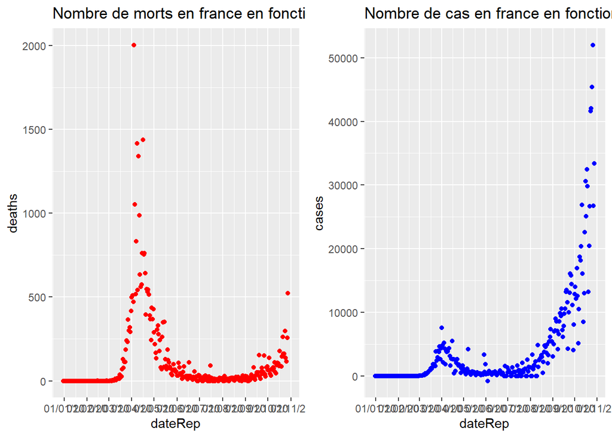

```r
grid.arrange(p1, p2,nrow = 1,ncol=2)
```

> quel est le mois où il y a le plus de cas en France et le mois où il y en a moins

```r
#isolons dans un objet le nombre de cas par mois
df2<-df %>%
  filter(countriesAndTerritories=="France") %>%
  group_by(year,month,countriesAndTerritories) %>%
  summarise_at(vars(cases),list(nbreCasMensuel = sum))
```

```r
#le mois où il y a le plus de cas en France
df3<-df2 %>% group_by(year,month,countriesAndTerritories) %>%
    mutate(mx = max(nbreCasMensuel)) %>%
    arrange(desc(mx), desc(nbreCasMensuel)) %>%
    select(-mx)
max<-df3[1,]
max
```

```
## # A tibble: 1 x 4
## # Groups:   year, month, countriesAndTerritories [1]
##    year month countriesAndTerritories nbreCasMensuel
##   <int> <int> <chr>                            <int>
## 1  2020    10 France                          648005
```

```r
#le mois où il y a le moins de cas en France
min<-df3[11,]
min
```

```
## # A tibble: 1 x 4
## # Groups:   year, month, countriesAndTerritories [1]
##    year month countriesAndTerritories nbreCasMensuel
##   <int> <int> <chr>                            <int>
## 1  2019    12 France                               0
```

> nombre total de cas en France

```r
nbreTotCas<-sum(df3$nbreCasMensuel)
nbreTotCas
```

```
## [1] 1198695
```

## Graphe de morts en France,Italie,Espagne, Allemagne et Royaume Uni

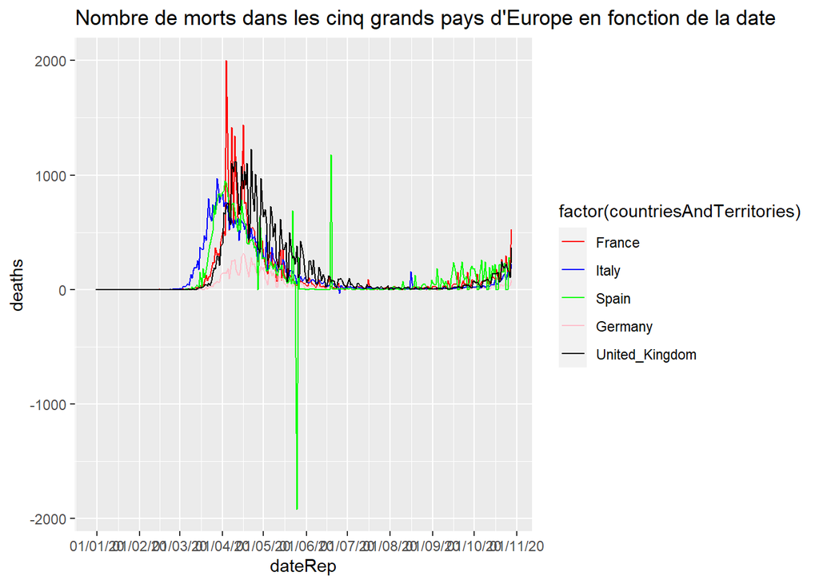

```r
p3<-df %>%
  filter(countriesAndTerritories %in% c("France","Italy","Spain","Germany","United_Kingdom")) %>%
  group_by(countriesAndTerritories,dateRep) %>%
  ggplot() +
  geom_line(aes(x=dateRep,y=deaths,color=factor(countriesAndTerritories)))+
  scale_color_manual(breaks = c("France", "Italy", "Spain","Germany","United_Kingdom"),
                                         values=c("red", "blue", "green","pink","black")) +
  ggtitle("Nombre de morts dans les cinq grands pays d'Europe en fonction de la date") +
  scale_x_date(breaks = date_breaks("1 month"),labels = date_format("%d/%m/%y"),
               limits = as.Date(c("2019-12-31","2020-10-28")))
p3
```

## Continent avec le plus de cas de covid

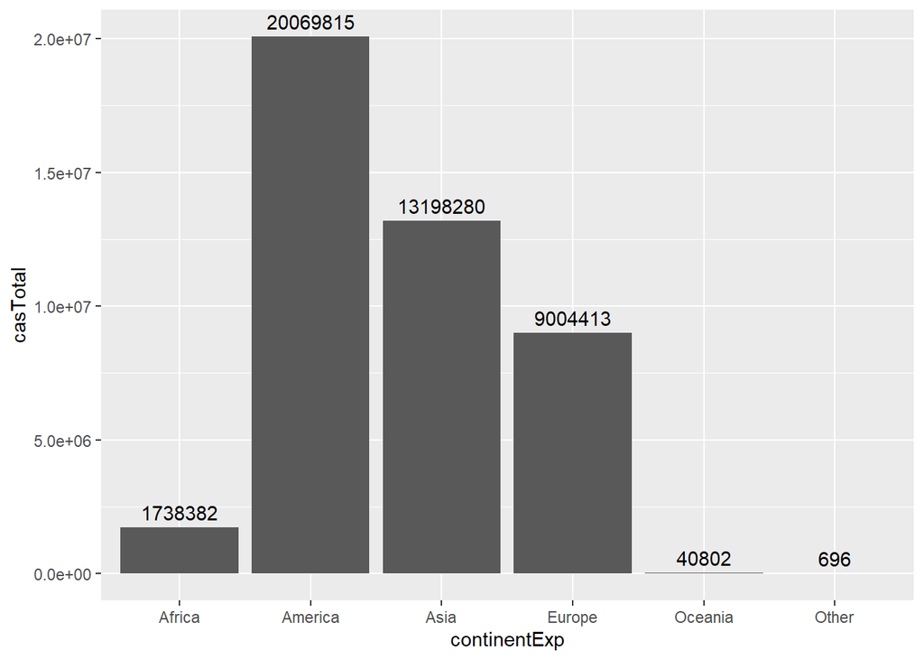

```r
p4<-df %>%
  group_by(continentExp) %>%
  summarise_at(vars(cases),list(casTotal = sum)) %>%
  ggplot(aes(x=continentExp,y=casTotal)) +
  geom_col() +
  geom_text(aes(label=casTotal),vjust=-0.5)
p4
```

## Pays avec le plus de cas de covid

```r
df4<-df %>%
  group_by(countriesAndTerritories) %>%
  summarise_at(vars(cases),list(casTotal = sum)) %>%
  mutate(mx1 = max(casTotal)) %>%
  arrange(desc(mx1), desc(casTotal)) %>%
  select(-mx1,countriesAndTerritories) %>%
  head(1)
df4
```

```
## # A tibble: 1 x 2
##   countriesAndTerritories  casTotal
##   <chr>                       <int>
## 1 United_States_of_America  8779653
```

## Taux de létalité dans chaque pays (nombre de décès par rapport au nombre de cas)

```r
df5<-df %>%
   group_by(countriesAndTerritories) %>%
   mutate(countriesAndTerritories,casT=sum(cases),deathsT=sum(deaths),tauxLet=deathsT*100/casT) %>%
   select(countriesAndTerritories,casT,deathsT,tauxLet,popData2019) %>%
   distinct(countriesAndTerritories,.keep_all=TRUE)
df5
```

```
## # A tibble: 212 x 5
## # Groups:   countriesAndTerritories [212]
##    countriesAndTerritories    casT deathsT tauxLet popData2019
##    <chr>                     <int>   <int>   <dbl>       <int>
##  1 Afghanistan               41145    1529   3.72     38041757
##  2 Albania                   19729     487   2.47      2862427
##  3 Algeria                   56706    1931   3.41     43053054
##  4 Andorra                    4410      72   1.63        76177
##  5 Angola                     9644     270   2.80     31825299
##  6 Anguilla                      3       0   0           14872
##  7 Antigua_and_Barbuda         124       3   2.42        97115
##  8 Argentina               1116596   29730   2.66     44780675
##  9 Armenia                   82651    1243   1.50      2957728
## 10 Aruba                      4420      36   0.814      106310
## # ... with 202 more rows
```

> taux de létalité en France

```r
df5 %>%
  filter(countriesAndTerritories=="France")
```

```
## # A tibble: 1 x 5
## # Groups:   countriesAndTerritories [1]
##   countriesAndTerritories    casT deathsT tauxLet popData2019
##   <chr>                     <int>   <int>   <dbl>       <int>
## 1 France                  1198695   35541    2.96    67012883
```

## Taux de mortalité de chaque pays (nombre de décés par rapport à la population générale)

```r
df6 <- df5 %>%
  group_by(countriesAndTerritories) %>%
  mutate(tauxMort=deathsT*100/popData2019) %>%
  select(countriesAndTerritories,casT,deathsT,tauxLet,tauxMort,popData2019)
df6
```

```
## # A tibble: 212 x 6
## # Groups:   countriesAndTerritories [212]
##    countriesAndTerritories    casT deathsT tauxLet tauxMort popData2019
##    <chr>                     <int>   <int>   <dbl>    <dbl>       <int>
##  1 Afghanistan               41145    1529   3.72  0.00402     38041757
##  2 Albania                   19729     487   2.47  0.0170       2862427
##  3 Algeria                   56706    1931   3.41  0.00449     43053054
##  4 Andorra                    4410      72   1.63  0.0945         76177
##  5 Angola                     9644     270   2.80  0.000848    31825299
##  6 Anguilla                      3       0   0     0              14872
##  7 Antigua_and_Barbuda         124       3   2.42  0.00309        97115
##  8 Argentina               1116596   29730   2.66  0.0664      44780675
##  9 Armenia                   82651    1243   1.50  0.0420       2957728
## 10 Aruba                      4420      36   0.814 0.0339        106310
## # ... with 202 more rows
```

> taux de mortalité en France

```r
df6 %>%
  filter(countriesAndTerritories=="France")
```

```
## # A tibble: 1 x 6
## # Groups:   countriesAndTerritories [1]
##   countriesAndTerritories    casT deathsT tauxLet tauxMort popData2019
##   <chr>                     <int>   <int>   <dbl>    <dbl>       <int>
## 1 France                  1198695   35541    2.96   0.0530    67012883
```

## Corrélation et régression linéaire

```r
x=df6$casT
y=df6$deathsT
```

> faisons un plot

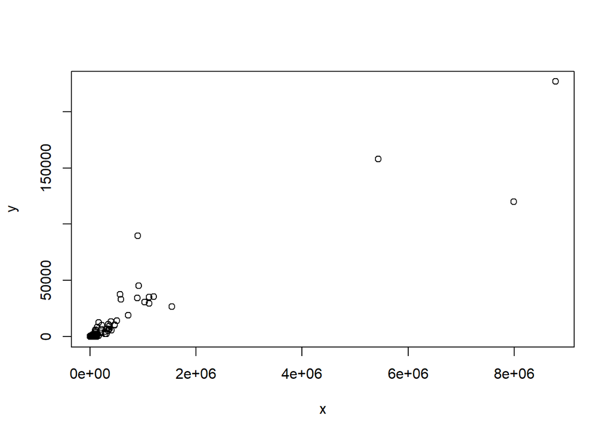

```r
plot(x,y)
```

> faisons un test de corrélation linéaire pour évaluer la dépendance entre les deux variables

```r
cor(x,y,method = "pearson")
```

```
## [1] 0.937049
```

> régression de y en fonction de x

```r
lm(y~x)
```

```
##
## Call:
## lm(formula = y ~ x)
##
## Coefficients:
## (Intercept)            x
##   735.86483      0.02297
```

> traçons la droite de régression y en fonction de x

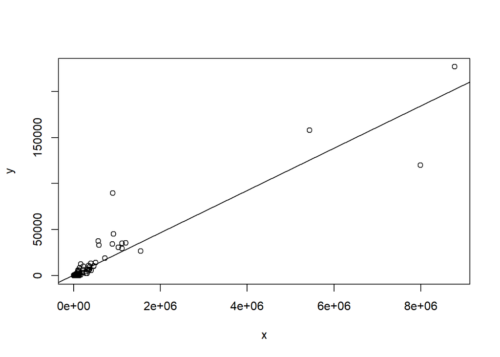

```r
plot(x,y)
abline(lm(y~x))
```

## Diagramme en barre du nombre de cas Total de chaque pays par continent

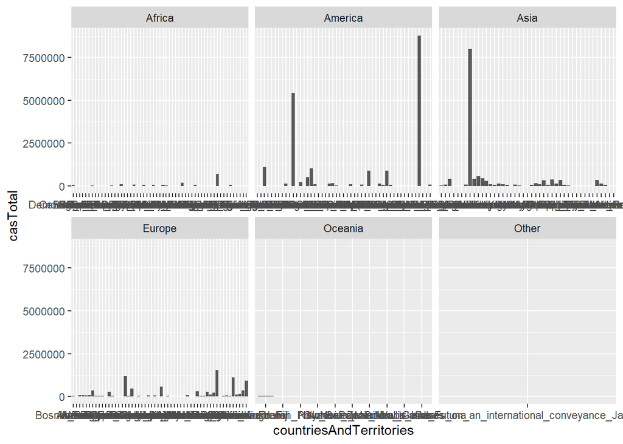

```r
df7<-df %>%
    group_by(continentExp,countriesAndTerritories) %>%
    summarise_at(vars(cases),list(casTotal= sum)) %>%
    ggplot(aes(x=countriesAndTerritories,y=casTotal))+
    geom_col() +
    facet_wrap(~continentExp, scale="free_x")
df7
```